# ENVS215 Applied Practical Assessment: Pokemon Battles

## 201370816

### 15/05/18

In the late 1990's and early 2000's, the Pokemon media franchise took over much of youth culture, taking the form of video games, an associated card trading game, a television series, and even films. The idea behind all of these was that humans (known as trainers) would capture and train fictional creatures of various shapes, sizes and types (known as pokemon) with the aim of training them and battling the against each other [2]. The franchise has gone through a number of iterations, releasing new trainer features, new pokemon and exploring new fictional realms. In recent years, interest in the franchise has been revitalised by the development of an augmented reality game (known as Pokemon GO) which allows players to become real-life pokemon trainers by capturing pokemon in the real world using their phones, and meeting up with other trainers to battle.

[figure not shown]

Given this renewed interest, and the recent surge in data scientific investigations, I have decided to apply my data skills to data relating to the franchise.

The data for this investigation was obtained from the Kaggle challenge titled **[Pokemon - Weedle's Cave](https://www.kaggle.com/terminus7/pokemon-challenge)**. The aim of the Kaggle challenge is to use the provided data to build a model that will accurately predict the winner in a one-on-one battle between two pokemon. To this end, the challenge provides three datafiles:

- `pokemon.csv` - metadata relating to each of the pokemon
- `combats.csv` - a collection of one-on-one battles between pokemon, with a winner
- `test.csv` - a dataset for testing predictive modelling of battle winners

Whilst the challenge sets the task of predicting the winner in a battle, this investigation will go a step further - looking to also cluster the pokemon using some unsupervised learning techniques - and will therefore be structured as follows:

- 0. Preamble: Loading required packages and datasets.
- 1. Data Preparation: Taking a first look at the data, identifying missing values and other data issues, and fixing them where posssible.
- 2. Exploratory Data Visualisation: Visualising the data to gain insight into the trends that can be found.
- 3. Unsupervised Learning: Clustering pokemon based on their win ratio against other pokemon types with a view to reconstructing the pokemon type dominance chart.
- 4. Supervised Learning: Exploring a variety of predictive models with a view to exploring which model provides the best predictive outputs.

## 0. Preamble

Before getting into the investigation, let us first import the packages that we are going to use:

- `matplotlib`: visualisation
- `numpy`: numerical calculations
- `pandas`: data manipulation
- `seaborn`: visualisation
- `sklearn`: data modelling

```python
# Import packages
import pandas as pd
import numpy as np
import seaborn as sns
import matplotlib.pyplot as plt
import matplotlib.colors as colors
import matplotlib.cm as cmx
# sklearn unsupervised
from sklearn import cluster, neighbors
# sklearn supervised
from sklearn import ensemble, linear_model, neural_network, tree
# sklearn others
from sklearn import cross_validation, decomposition, metrics, model_selection, preprocessing

# Ensure that figures are inline
%matplotlib inline
```

We can then read each of the relavant datafiles into pandas dataframes from a relative filepath. It is worth noting at this stage that this investigation will make no use of the `test.csv` datafile, as the aim of the predictive element here is simply to build a model, and to validate it.

```python
dataPath = '../../datasets/pokemon-challenge/{0}.csv'
combats = pd.read_csv(dataPath.format('combats'))
pokemon = pd.read_csv(dataPath.format('pokemon'))
```

## 1. Data Preparation

The aim of this section is to take an initial look at the data, identify any data issues, and attempt to remedy them. With this in mind, we will go through each of the datafiles one at a time.

### 1.1 `pokemon.csv`

First let's look at the pokemon metadata dataframe, and get an understanding of what the data looks like inside.

```python
pokemon.info()
pokemon.head()
```

```
<class 'pandas.core.frame.DataFrame'>
RangeIndex: 800 entries, 0 to 799
Data columns (total 12 columns):
#             800 non-null int64
Name          799 non-null object
Type 1        800 non-null object
Type 2        414 non-null object
HP            800 non-null int64
Attack        800 non-null int64
Defense       800 non-null int64
Sp. Atk       800 non-null int64
Sp. Def       800 non-null int64
Speed         800 non-null int64
Generation    800 non-null int64
Legendary     800 non-null bool
dtypes: bool(1), int64(8), object(3)
memory usage: 69.6+ KB
```

|  | # | Name | Type 1 | Type 2 | HP | Attack | Defense | Sp. Atk | Sp. Def | Speed | Generation | Legendary |
| --- | --- | --- | --- | --- | --- | --- | --- | --- | --- | --- | --- | --- |
| 0 | 1 | Bulbasaur | Grass | Poison | 45 | 49 | 49 | 65 | 65 | 45 | 1 | False |
| 1 | 2 | Ivysaur | Grass | Poison | 60 | 62 | 63 | 80 | 80 | 60 | 1 | False |
| 2 | 3 | Venusaur | Grass | Poison | 80 | 82 | 83 | 100 | 100 | 80 | 1 | False |
| 3 | 4 | Mega Venusaur | Grass | Poison | 80 | 100 | 123 | 122 | 120 | 80 | 1 | False |
| 4 | 5 | Charmander | Fire | NaN | 39 | 52 | 43 | 60 | 50 | 65 | 1 | False |

So we can see that in this dataframe, we have 800 rows each containing metadata pertaining to an individual pokemon, covering the following factors:

- Pokemon number (`#`)
- `Name`
- Primary type (`Type 1`)
- Secondary type (`Type 2`)
- Battle attributes (`HP` - otherwise known as hit points (https://bulbapedia.bulbagarden.net/wiki/Statistic), `Attack`, `Defense`, `Sp. Atk` or Special Attack, `Sp. Def` or Special Defense and `Speed`)
- `Generation` - the generation of the franchise in which the pokemon first appeared
- `Legendary` - a boolean value indicating whether the pokemon is legendary or not

Looking at this data, there are some simple points to note:

1. The `#` column is essentially our id number - whilst this is a purely cosmetic issue, we will go ahead and call it that. We will probably need to do the same thing when we come to look at the combats dataframe.
2. The `Name` column appears to have one missing value - given that it's just one, a little manual input may be in order/
3. Almost half of the pokemon don't appear to have a `Type 2` - is this unusual? (I don't think so...).

We will now proceed to address each of these issues.

#### 1.1.1 Fixing id column

We'll start off with first fixing the `id` column by renaming it as such.

```python
# Renaming column to id
pokemon.rename(columns={'#':'id'}, inplace = True)
pokemon.head()
```

|  | id | Name | Type 1 | Type 2 | HP | Attack | Defense | Sp. Atk | Sp. Def | Speed | Generation | Legendary |
| --- | --- | --- | --- | --- | --- | --- | --- | --- | --- | --- | --- | --- |
| 0 | 1 | Bulbasaur | Grass | Poison | 45 | 49 | 49 | 65 | 65 | 45 | 1 | False |
| 1 | 2 | Ivysaur | Grass | Poison | 60 | 62 | 63 | 80 | 80 | 60 | 1 | False |
| 2 | 3 | Venusaur | Grass | Poison | 80 | 82 | 83 | 100 | 100 | 80 | 1 | False |
| 3 | 4 | Mega Venusaur | Grass | Poison | 80 | 100 | 123 | 122 | 120 | 80 | 1 | False |
| 4 | 5 | Charmander | Fire | NaN | 39 | 52 | 43 | 60 | 50 | 65 | 1 | False |

#### 1.1.2 Identifying pokemon with missing name

Let's first of all find the row pertaining to the pokemon with a missing name.

```python
# Finding missing pokemon name
pokemon[pokemon['Name'].isna()]
```

|  | id | Name | Type 1 | Type 2 | HP | Attack | Defense | Sp. Atk | Sp. Def | Speed | Generation | Legendary |
| --- | --- | --- | --- | --- | --- | --- | --- | --- | --- | --- | --- | --- |
| 62 | 63 | NaN | Fighting | NaN | 65 | 105 | 60 | 60 | 70 | 95 | 1 | False |

So it's the pokemon with `id==63`. In order to work out what it's name is, we'll need to do a little bit of searching on the internet. Looking at the Pokemon database [4], it looks like this is Primeape.

[figure not shown]

```python
# Input name
pokemon.loc[62,'Name'] = 'Primeape'
# Check for NaNs again
pokemon[pokemon['Name'].isna()]
```

|  | id | Name | Type 1 | Type 2 | HP | Attack | Defense | Sp. Atk | Sp. Def | Speed | Generation | Legendary |
| --- | --- | --- | --- | --- | --- | --- | --- | --- | --- | --- | --- | --- |

All fixed.

#### 1.1.3 Looking at pokemon who don't have `Type 2`

Let's now look at the pokemon that don't have a value for `Type 2`. We'll start off by getting a basic description of these pokemon.

```python
# Subset of pokemon that don't have a Type 2
missingType2 = pokemon[pokemon['Type 2'].isna()]
missingType2.info()
missingType2.head()
```

```
<class 'pandas.core.frame.DataFrame'>
Int64Index: 386 entries, 4 to 792
Data columns (total 12 columns):
id            386 non-null int64
Name          386 non-null object
Type 1        386 non-null object
Type 2        0 non-null object
HP            386 non-null int64
Attack        386 non-null int64
Defense       386 non-null int64
Sp. Atk       386 non-null int64
Sp. Def       386 non-null int64
Speed         386 non-null int64
Generation    386 non-null int64
Legendary     386 non-null bool
dtypes: bool(1), int64(8), object(3)
memory usage: 36.6+ KB
```

|  | id | Name | Type 1 | Type 2 | HP | Attack | Defense | Sp. Atk | Sp. Def | Speed | Generation | Legendary |
| --- | --- | --- | --- | --- | --- | --- | --- | --- | --- | --- | --- | --- |
| 4 | 5 | Charmander | Fire | NaN | 39 | 52 | 43 | 60 | 50 | 65 | 1 | False |
| 5 | 6 | Charmeleon | Fire | NaN | 58 | 64 | 58 | 80 | 65 | 80 | 1 | False |
| 9 | 10 | Squirtle | Water | NaN | 44 | 48 | 65 | 50 | 64 | 43 | 1 | False |
| 10 | 11 | Wartortle | Water | NaN | 59 | 63 | 80 | 65 | 80 | 58 | 1 | False |
| 11 | 12 | Blastoise | Water | NaN | 79 | 83 | 100 | 85 | 105 | 78 | 1 | False |

From the rows that `head()` has provided us above, I don't think there's anything surprising about these pokemon not having a `Type 2`; these pokemon appear to be those that are clearly a single type - pokemon that we will denote as 'pure'.

It would be interesting to see how the lack of `Type 2` varies with `Generation` and `Type 1` - something that we can go on to explore in the Exploratory Data Visualisation section.

Whilst we are considering types, are there any types that appear as part of `Type 1` but not `Type 2` (or vice-versa)?

```python
# Identify unique values in each, disregarding Type2==NaN
type1Set = set(pokemon['Type 1'].dropna().unique())
type2Set = set(pokemon['Type 2'].dropna().unique())

# Get asymmetric differences in each case
print('In Type 1 but not Type 2: {0}'.format(type1Set.difference(type2Set)))
print('In Type 2 but not Type 1: {0}'.format(type2Set.difference(type1Set)))
```

```
In Type 1 but not Type 2: set()
In Type 2 but not Type 1: set()
```

So it appears that all of the types that appear in the `Type 1` column also appear in the `Type 2` column, nor vice-versa. This is exactly what we would like to see. We can, therefore, go ahead and construct a set of all of the valid types which we will make use of later.

```python
allTypes = type1Set.union(type2Set)
```

#### 1.1.4 Creating `Total` summary stat

Finally, let's construct a new variable for each pokemon: the total stat for, i.e. the sum of all of the other numeric attributes of each pokemon. This may be of use when we come to do some data modelling.

```python
# Make list of attribute column names
statCols = ['HP', 'Attack', 'Defense', 'Sp. Atk', 'Sp. Def', 'Speed']
# Make total column
pokemon['Total'] = pokemon[statCols].apply(np.sum, axis=1)
```

```python
pokemon.info()
pokemon.head()
```

```
<class 'pandas.core.frame.DataFrame'>
RangeIndex: 800 entries, 0 to 799
Data columns (total 13 columns):
id            800 non-null int64
Name          800 non-null object
Type 1        800 non-null object
Type 2        414 non-null object
HP            800 non-null int64
Attack        800 non-null int64
Defense       800 non-null int64
Sp. Atk       800 non-null int64
Sp. Def       800 non-null int64
Speed         800 non-null int64
Generation    800 non-null int64
Legendary     800 non-null bool
Total         800 non-null int64
dtypes: bool(1), int64(9), object(3)
memory usage: 75.9+ KB
```

|  | id | Name | Type 1 | Type 2 | HP | Attack | Defense | Sp. Atk | Sp. Def | Speed | Generation | Legendary | Total |
| --- | --- | --- | --- | --- | --- | --- | --- | --- | --- | --- | --- | --- | --- |
| 0 | 1 | Bulbasaur | Grass | Poison | 45 | 49 | 49 | 65 | 65 | 45 | 1 | False | 318 |
| 1 | 2 | Ivysaur | Grass | Poison | 60 | 62 | 63 | 80 | 80 | 60 | 1 | False | 405 |
| 2 | 3 | Venusaur | Grass | Poison | 80 | 82 | 83 | 100 | 100 | 80 | 1 | False | 525 |
| 3 | 4 | Mega Venusaur | Grass | Poison | 80 | 100 | 123 | 122 | 120 | 80 | 1 | False | 625 |
| 4 | 5 | Charmander | Fire | NaN | 39 | 52 | 43 | 60 | 50 | 65 | 1 | False | 309 |

### 1.2 `combats.csv`

We can now move on to looking at the combats dataset. Once again, we will begin by simply gaining some summary information about the dataframe.

```python
# Get summary information about combats data
combats.info()
combats.head()
```

```
<class 'pandas.core.frame.DataFrame'>
RangeIndex: 50000 entries, 0 to 49999
Data columns (total 3 columns):
First_pokemon     50000 non-null int64
Second_pokemon    50000 non-null int64
Winner            50000 non-null int64
dtypes: int64(3)
memory usage: 1.1 MB
```

|  | First_pokemon | Second_pokemon | Winner |
| --- | --- | --- | --- |
| 0 | 266 | 298 | 298 |
| 1 | 702 | 701 | 701 |
| 2 | 191 | 668 | 668 |
| 3 | 237 | 683 | 683 |
| 4 | 151 | 231 | 151 |

This doesn't look at all unusual; we have 50,000 rows pertaining to one-on-one battles, each of which contain the following information about each of the battles:

- `First_pokemon` - the id of the pokemon that attacks first in the battle
- `Second_pokemon` - the id of the other pokemon involved in the battle
- `Winner` - the id of the winning pokemon

However, we would like to dig a little deeper and conduct some checks on the data that is contained herein. We'll start by ensuring that in each battle, the winner is valid; that is to say that the id of the winner is that of one of the two battling pokemon, and that it is one of those contained in the pokemon metadata dataframe.

```python
# Check that the winner is one of the battling pokemon
validPokemon = pokemon['id'].unique()

def checkValidWinner(row):
    """Function to check whether winning pokemon is valid.
    This checks that the winner is both
        (a) one of the two combatants, and
        (b) in the pokemon metadata dataframe.
    :params: row, dataframe row
    :returns: validWinner, boolean"""
    combatants = [row['First_pokemon'], row['Second_pokemon']]
    winner = row['Winner']
    if winner in combatants and winner in validPokemon:
        return True
    else:
        return False

# Apply checkValidWinner to every row of the combats dataframe
# Make a new column (validWinner) with the resulting boolean
combats['validWinner'] = combats.apply(checkValidWinner, axis=1)

# Check results
print(combats.info())
# This should be 1
print('Proportion of winners that are valid: '\
      '{0}'.format(combats['validWinner'].sum()/len(combats)))
combats.head()
```

```
<class 'pandas.core.frame.DataFrame'>
RangeIndex: 50000 entries, 0 to 49999
Data columns (total 4 columns):
First_pokemon     50000 non-null int64
Second_pokemon    50000 non-null int64
Winner            50000 non-null int64
validWinner       50000 non-null bool
dtypes: bool(1), int64(3)
memory usage: 1.2 MB
None
Proportion of winners that are valid: 1.0
```

|  | First_pokemon | Second_pokemon | Winner | validWinner |
| --- | --- | --- | --- | --- |
| 0 | 266 | 298 | 298 | True |
| 1 | 702 | 701 | 701 | True |
| 2 | 191 | 668 | 668 | True |
| 3 | 237 | 683 | 683 | True |
| 4 | 151 | 231 | 151 | True |

So the output is exactly what we wanted, and it appears that the winner of each battle is valid.

We will now move on to augmenting the combats dataset by adding in the primary type of each of the combatants. This will be achieved by first isolating the primary types that pertain to each pokemon id from the pokemon metadata dataset; this information will then be joined to the combats dataset using an inner join to ensure that we only get the types of the pokemon that arise in the combats dataset.

```python
# Add types of First_pokemon from pokemon dataset
pokemonTypes = pokemon[['id', 'Type 1']]
combats = combats.merge(right=pokemonTypes,
                        left_on='First_pokemon', right_on='id',
                        how='inner')
combats = combats.rename({'Type 1': 'First_pokemon_type'}, axis=1)
combats = combats.drop('id', axis=1)
```

```python
combats.info()
combats.head()
```

```
<class 'pandas.core.frame.DataFrame'>
Int64Index: 50000 entries, 0 to 49999
Data columns (total 5 columns):
First_pokemon         50000 non-null int64
Second_pokemon        50000 non-null int64
Winner                50000 non-null int64
validWinner           50000 non-null bool
First_pokemon_type    50000 non-null object
dtypes: bool(1), int64(3), object(1)
memory usage: 2.0+ MB
```

|  | First_pokemon | Second_pokemon | Winner | validWinner | First_pokemon_type |
| --- | --- | --- | --- | --- | --- |
| 0 | 266 | 298 | 298 | True | Rock |
| 1 | 266 | 301 | 301 | True | Rock |
| 2 | 266 | 304 | 266 | True | Rock |
| 3 | 266 | 247 | 247 | True | Rock |
| 4 | 266 | 690 | 690 | True | Rock |

```python
# Add types of Second_pokemon from pokemon dataset
combats = combats.merge(right=pokemonTypes,
                        left_on='Second_pokemon', right_on='id',
                        how='inner')
combats = combats.rename({'Type 1': 'Second_pokemon_type'}, axis=1)
combats = combats.drop('id', axis=1)
combats.info()
combats.head()
```

```
<class 'pandas.core.frame.DataFrame'>
Int64Index: 50000 entries, 0 to 49999
Data columns (total 6 columns):
First_pokemon          50000 non-null int64
Second_pokemon         50000 non-null int64
Winner                 50000 non-null int64
validWinner            50000 non-null bool
First_pokemon_type     50000 non-null object
Second_pokemon_type    50000 non-null object
dtypes: bool(1), int64(3), object(2)
memory usage: 2.3+ MB
```

|  | First_pokemon | Second_pokemon | Winner | validWinner | First_pokemon_type | Second_pokemon_type |
| --- | --- | --- | --- | --- | --- | --- |
| 0 | 266 | 298 | 298 | True | Rock | Grass |
| 1 | 73 | 298 | 298 | True | Fighting | Grass |
| 2 | 373 | 298 | 298 | True | Water | Grass |
| 3 | 536 | 298 | 536 | True | Electric | Grass |
| 4 | 368 | 298 | 368 | True | Normal | Grass |

And there we have it - a dataframe containing the types of both of the combatants in each of the battles.

## 2. Exploratory Data Visualisation

In this section we shall undertake some exploratory data visualisation with a view exploring some of the trends that arise in the data. To start with, we shall have a look at the distributions of each of the numerical attributes across all of the pokemon

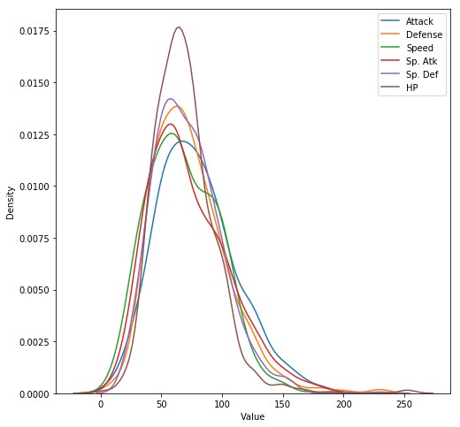

```python
# Plot kde's showing distributions of attack, defense, speed, sp attack, sp defense and hp
statCols = ['Attack', 'Defense', 'Speed',
           'Sp. Atk', 'Sp. Def', 'HP']
plt.figure(figsize=(8,8))
for col in statCols:
    sns.kdeplot(pokemon[col])
plt.xlabel('Value')
plt.ylabel('Density')
plt.show()
```

From the above figure, it would appear that each of the stats are relatively similarly distributed. This is to be expected, particularly when considering opposing attributes such as attack and defence; having one be typically higher than the other would skew the dynamics of the game.

It is also worth noting that each of the attributes appear to vary quite widely; whilst some weaker pokemon may have statistics close to 0, some of the stronger pokemon have statistics nearing 200. Whilst these values are somewhat arbitrary, the fact that the modal attribute values are typically around 50-60 indicates that the strongest pokemon are likely significantly stronger than their opponents.

We can now look at how these attributes vary across different primary types. When doing this, we will only consider cases where there exist at least 50 pokemon of a given type.

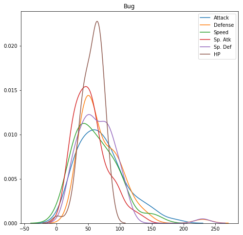

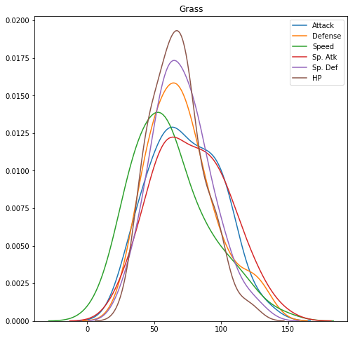

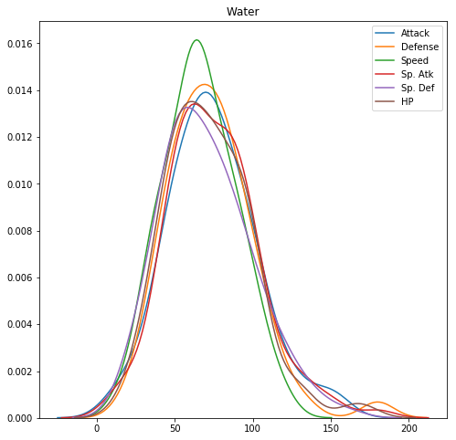

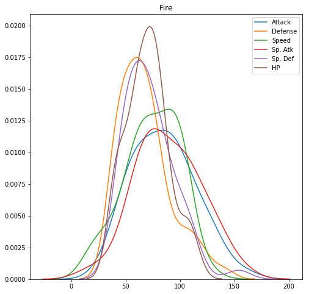

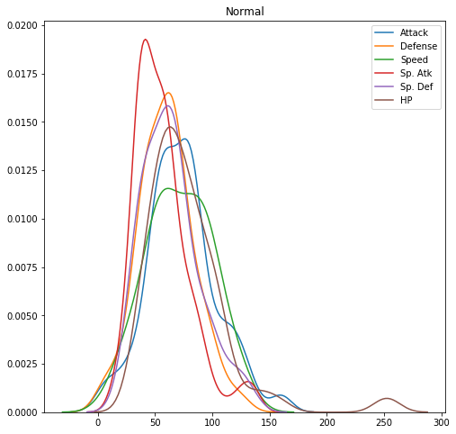

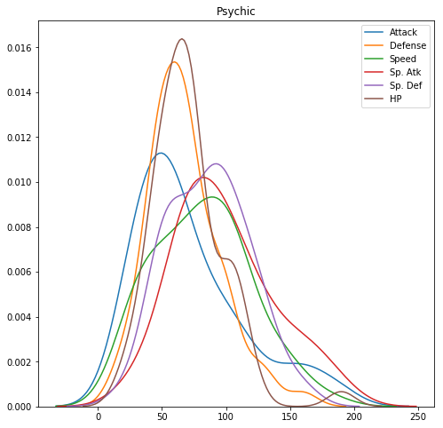

```python
# Visualising the distribution of each attribute for abundant types
for pokeType in allTypes:
    # Ensure we have enough pokemon in sample
    if len(pokemon[pokemon['Type 1']==pokeType])>50:
        plt.figure(figsize=(8,8))
        # Plot each attribute
        for col in statCols:
            sns.kdeplot(pokemon[pokemon['Type 1']==pokeType][col], label=col)
        plt.title(pokeType)
        plt.show()
```

From the above plots, we can see how each of the attributes varies for each of the types. This can be use to display where certain types overachieve and where they are typically deficient.

Of the six types shown, Water appears to be the most well rounded with the distribution of each attribute being relatively similar. The relative strengths and weaknesses of each of these types can be seen in the following table:

| Type | Strengths | Weaknesses |
| --- | --- | --- |
| Bug | HP, Attack | Sp. Atk, Speed |
| Water | - | - |
| Normal | Attack, Speed | Sp. Atk |
| Grass | - | Speed |
| Psychic | Speed, Sp. Atk, Sp. Def | Attack |
| Fire | Attack, Sp. Atk, Speed | Defense, Sp. Def |

Given the finding in the Data Preparation stage that many pokemon lack a value for `Type 2`, it would be interesting to see how the lack of `Type 2` varies with `Generation` and `Type 1`. To do this, we'll create a generic function that we can then apply to every row of the dataframe, plotting the variation in the number of pokemon lacking `Type 2` by a chosen factor.

```python
def plotMissingType2By(column):
    """Function to visualise how the number of pokemon that don't have a Type 2 varies."""
    # Make dataframe of number of pokemon missing Type 2 by chosen column
    missingColumn = missingType2[column].value_counts().to_frame()

    # Plot bar chart
    missingColumn.plot.bar(y=column,
                                legend=False,
                                figsize=(8, 8))
    # Add axis labels
    plt.xlabel(column)
    plt.ylabel('Number of pokemon missing Type 2')
    plt.show()
```

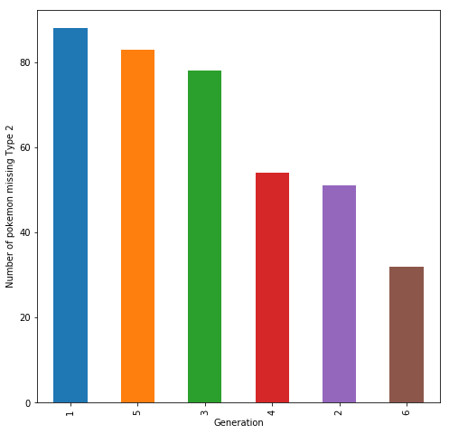

```python
# Plot by generation
plotMissingType2By('Generation')
```

From this we can see that the first generation has the greatest number of pure pokemon. Interestingly, it appears that the odd generations have more pure pokemon, whilst the even generations have fewer. It would be interesting to see how these numbers varied relative to the total number of pokemon in each generation.

Let us now look at how the number of pokemon lacking `Type 2` varies with `Type 1`.

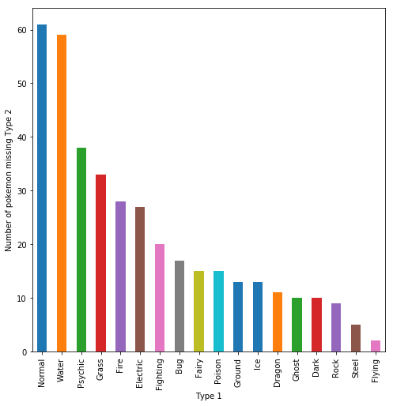

```python
# Plot by Type 1
plotMissingType2By('Type 1')
```

Above we see the variation in the number of pure pokemon by their `Type 1`. We can see that by far the most common pure types are `Normal` and `Water`, with approximately 60 pokemon of each type being pure. At the other end of the spectrum are `Flying` pokemon; this type rarely lends itself to being pure, that is to say that it is frequently used as a primary types to which to join a secondary type. Once again, it would likely be useful to see how this varies on a proportional basis.

Let us therefore define a new function that produces a similar set of bar charts, but this time taken as a proportion.

```python
def plotMissingType2ProportionBy(column):
    """Function to visualise how the proportion of pokemon that don't have a Type 2 varies."""

    # Make dataframe of proportion of pokemon missing Type 2 by chosen column
    missingColumn = missingType2[column].value_counts().to_frame()
    missingColumn['Total'] = pokemon[column].value_counts()
    # Calculate proportion
    missingColumn['Proportion'] = missingColumn[column] / missingColumn['Total']
    missingColumn = missingColumn.sort_values(by='Proportion', ascending=False)
    print(missingColumn)

    # Plot bar chart
    missingColumn['Proportion'].plot.bar(y=column,
                                legend=False,
                                figsize=(8, 8))
    # Plot horizontal line of mean proportion
    plt.axhline(y=missingColumn['Proportion'].mean(), color='black',
                linestyle='--', alpha=0.5)
    # Add axis labels
    plt.xlabel(column)
    plt.ylabel('Proportion of pokemon missing Type 2')
    plt.show()
```

```
   Generation  Total  Proportion
1          88    166    0.530120
5          83    165    0.503030
3          78    160    0.487500
2          51    106    0.481132
4          54    121    0.446281
6          32     82    0.390244
```

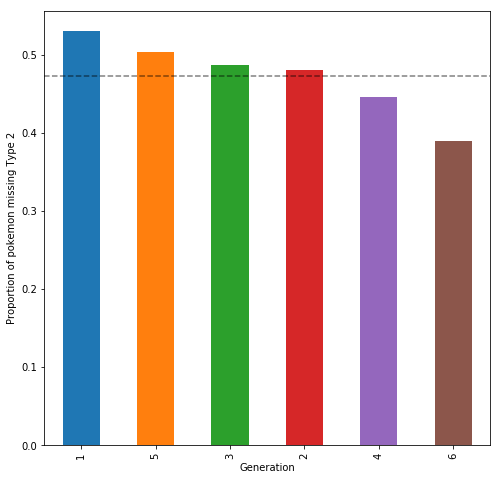

```python
plotMissingType2ProportionBy('Generation')
```

Looking at how the proportions vary, we can see that the odd generations have the largest proportion of pure pokemon; however, the difference between odd and even generations is not as great. It is likely that the greater discrepancy observed in the previous figure was a result of fewer new pokemon being released in the even generations.

```
          Type 1  Total  Proportion
Fairy         15     17    0.882353
Fighting      20     27    0.740741
Psychic       38     57    0.666667
Normal        61     98    0.622449
Electric      27     44    0.613636
Ice           13     24    0.541667
Fire          28     52    0.538462
Poison        15     28    0.535714
Water         59    112    0.526786
Flying         2      4    0.500000
Grass         33     70    0.471429
Ground        13     32    0.406250
Dragon        11     32    0.343750
Dark          10     31    0.322581
Ghost         10     32    0.312500
Bug           17     69    0.246377
Rock           9     44    0.204545
Steel          5     27    0.185185
```

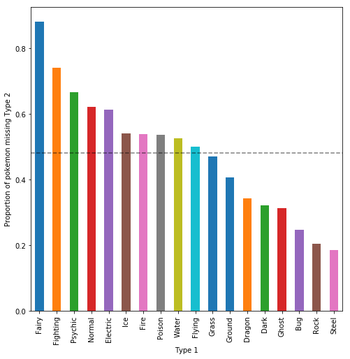

```python
plotMissingType2ProportionBy('Type 1')
```

In the case of the variation of the proportion of pure pokemon by `Type 1`, the plot tells a markedly different story to the above figure concering raw counts. The figure shows that almost all `Fairy` pokemon are pure. By raw count, we saw that `Normal` and `Water` pokemon were most commonly pure; however, viewing by proportion, we observe that this is simply a consequence of there being significantly more of each of these types. Whilst `Flying` type where least commony pure in raw terms, we see here that proportionally they are much closer to average (50% of `Flying` types are pure), indicating that the previous result was simply a consequence of there being so few pokemon that have `Flying` as their primary type.

## 3. Unsupervised Learning

Let us now move on to undertaking some unsupervised learning; this will take the form of a clustering exercise. The aim here will be to cluster the pokemon on their numerical attributes. An initial "educated-guess" for the value of $k$ will be the number of different types.

```python
# Initialise k-means with number of clusters = number of types
km = cluster.KMeans(n_clusters=len(allTypes))
km
```

```
KMeans(algorithm='auto', copy_x=True, init='k-means++', max_iter=300,
    n_clusters=18, n_init=10, n_jobs=1, precompute_distances='auto',
    random_state=None, tol=0.0001, verbose=0)
```

Let us now subset our pokemon metadata to the numerical attributes that we would like to use.

```python
statsCols = ['HP', 'Attack', 'Defense', 'Sp. Atk', 'Sp. Def', 'Speed']
pokemonStats = pokemon[statsCols]
```

Finally, let us fit our clusters

```python
np.random.seed(1234)
kmcls = km.fit(pokemonStats)
```

```python
kmcls.labels_[:20]
```

```
array([ 4,  4, 16,  6, 17, 11,  0,  6, 12,  4,  4, 16,  6, 14, 14,  4, 14,
       14, 11,  8], dtype=int32)
```

Now that each pokemon has been assigned a cluster, let us have a look at the clusters and the averages of the attributes associated with each of them.

```
0     45
1     37
2     18
3     61
4     67
5     82
6     30
7     16
8     55
9      3
10    59
11    75
12    20
13    33
14    49
15     8
16    59
17    83
dtype: int64
```

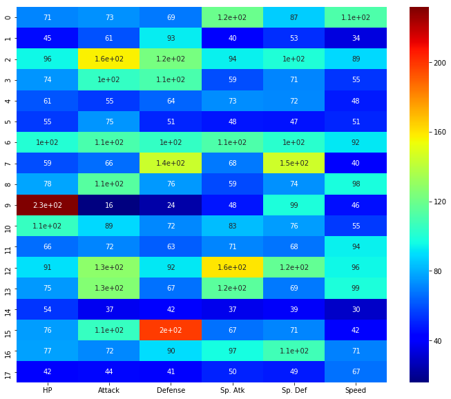

```python
# Get number of pokemon in each cluster
print(pokemon.groupby(kmcls.labels_).size())

# Heatmap of average attribute value for each cluster
plt.figure(figsize=(12,10))
sns.heatmap(pokemonStats.groupby(kmcls.labels_).mean(), cmap='jet', annot=True)
plt.show()
```

First of all, let us highlight a rather interesting results: cluster 9 has a very high average `HP` and a very low average `Attack`, whilst also have quite a wide range of other values; this is likely a consequence of the small number of samples that have been grouped into cluster 9. Cluster 15 also has a relatively low number of pokemon grouped to it.

Aside from these two smaller clusters, we can observe some clusters which could, perhaps, be associated with certain types given the following characterisations:

- 0: High `Sp. Atk` and `Speed`
- 1: High `Defense`
- 2: High `Attack`, `Defense` and `Sp. Def`
- 3: High `Attack` and `Defense`
- 7: High `Defense` and `Sp. Def`
- 8: High `Attack` and `Speed`
- 10: High `HP`
- 11: High `Speed`
- 12: High `Attack`, `Sp. Atk` and `Sp. Def`
- 13: High `Attack` and `Sp. Atk`
- 16: High `Defense`, `Sp. Atk` and `Sp. Def`

Given the trends found during the Exploratory Data Visualisation, we might suggest the following relationships between the clusters and types:

- Bug: 10
- Normal: 8
- Psychic: 0
- Fire: 0, 8, 13

### Elbow method

One way of choosing an appropriate value for $k$ when carrying out k-means clustering is the Elbow method. This method involves running the algorithm for a large range of $k$, and then a plot is produced displaying the increase in variance explained by adding the marginal cluster [8]. The aim is to observe an inflection point somewhere in the resulting figure after which the inclusion of an additional cluster will not result in a significant increase in the variance explained. This idea is put into practice below.

```python
np.random.seed(1234)
# Define range of ks - 100 is rather a lot
kRange = range(1, 100)

# Initialise k-means for each k
clusterList = list()
for i in kRange:
    clusterList.append(cluster.KMeans(n_clusters=i))

# Get cluster scores or each one
scoreList = list()
for km in clusterList:
    score = km.fit(pokemonStats).score(pokemonStats)
    scoreList.append(score)
```

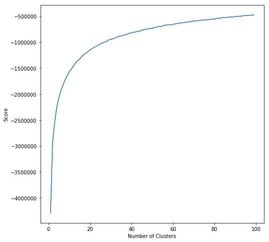

```python
# Plot figure showing variace explained by addition of cluster
plt.figure(figsize=(8,8))
plt.plot(kRange, scoreList)
plt.xlabel('Number of Clusters')
plt.ylabel('Score')
plt.show()
```

The above figure does not display a very clean point of inflection, and so it is not clear whether there is an appropriate single value for $k$ based on this approach; however, there is a noticeable change in gradient over the range $10<k<20$. This perhaps indicates that the choice of using the number of types for $k$ is not entirely incorrect, but that there are likely other factors which should be included into the process.

## 4. Supervised Learning

This section will deal with the development of models with the aim of predicting the the outcome of pokemon battles. Such a problem is one of binary classification - the model should predict of the combatants as the winner of the battle. As such, the models employed will be ones that are capable of responding with a binary response:

1. Logistic regression
2. Decision tree
3. Random Forest
4. Neural Network

### 4.1 Augmenting data

Before proceeding with the modelling process, the data will first be augmented. The first such augmentation is to ensure that the output variable is binary, i.e. either 0 (first pokemon) or 1 (second pokemon); we can do this as we have checked that all of the winners are valid. With that in mind, let's create a function that maps those for the whole combats dataset.

```python
# Create function to map to binary
def mapWinnerToBinary(row):
    winner = 0 if row['Winner'] == row['First_pokemon'] else 1
    return winner
```

```python
# Create new column for winner as a binary
combats['winnerBinary'] = combats.apply(mapWinnerToBinary, axis=1)
```

```python
# Check results
combats.info()
combats.head()
```

```
<class 'pandas.core.frame.DataFrame'>
Int64Index: 50000 entries, 0 to 49999
Data columns (total 7 columns):
First_pokemon          50000 non-null int64
Second_pokemon         50000 non-null int64
Winner                 50000 non-null int64
validWinner            50000 non-null bool
First_pokemon_type     50000 non-null object
Second_pokemon_type    50000 non-null object
winnerBinary           50000 non-null int64
dtypes: bool(1), int64(4), object(2)
memory usage: 2.7+ MB
```

|  | First_pokemon | Second_pokemon | Winner | validWinner | First_pokemon_type | Second_pokemon_type | winnerBinary |
| --- | --- | --- | --- | --- | --- | --- | --- |
| 0 | 266 | 298 | 298 | True | Rock | Grass | 1 |
| 1 | 73 | 298 | 298 | True | Fighting | Grass | 1 |
| 2 | 373 | 298 | 298 | True | Water | Grass | 1 |
| 3 | 536 | 298 | 536 | True | Electric | Grass | 0 |
| 4 | 368 | 298 | 368 | True | Normal | Grass | 0 |

Next, we would like to add the metadata pertaining to each of the combatants in each battle. In order to achieve this, we will once again define a function.

```python
def addPokemonStats(combatant):
    # Get relevant columns from pokemon metadata
    df = pokemon[['HP', 'Attack', 'Defense', 'Speed', 'Sp. Atk', 'Sp. Def', 'id']]
    # Make dictionary for renaming columns in df
    renameDict = {x: combatant + '_' + x for x in df.columns.values if x != 'id'}
    df = df.rename(renameDict, axis=1)
    newCombats = combats.merge(right=df, left_on=combatant, right_on='id', how='left')
    return newCombats.drop(['id'], axis=1)
```

```python
# Apply function to add metadata for first and second pokemon
combats = addPokemonStats('First_pokemon')
combats = addPokemonStats('Second_pokemon')
# Check results
combats.info()
combats.head()
```

```
<class 'pandas.core.frame.DataFrame'>
Int64Index: 50000 entries, 0 to 49999
Data columns (total 19 columns):
First_pokemon             50000 non-null int64
Second_pokemon            50000 non-null int64
Winner                    50000 non-null int64
validWinner               50000 non-null bool
First_pokemon_type        50000 non-null object
Second_pokemon_type       50000 non-null object
winnerBinary              50000 non-null int64
First_pokemon_HP          50000 non-null int64
First_pokemon_Attack      50000 non-null int64
First_pokemon_Defense     50000 non-null int64
First_pokemon_Speed       50000 non-null int64
First_pokemon_Sp. Atk     50000 non-null int64
First_pokemon_Sp. Def     50000 non-null int64
Second_pokemon_HP         50000 non-null int64
Second_pokemon_Attack     50000 non-null int64
Second_pokemon_Defense    50000 non-null int64
Second_pokemon_Speed      50000 non-null int64
Second_pokemon_Sp. Atk    50000 non-null int64
Second_pokemon_Sp. Def    50000 non-null int64
dtypes: bool(1), int64(16), object(2)
memory usage: 7.3+ MB
```

|  | First_pokemon | Second_pokemon | Winner | validWinner | First_pokemon_type | Second_pokemon_type | winnerBinary | First_pokemon_HP | First_pokemon_Attack | First_pokemon_Defense | First_pokemon_Speed | First_pokemon_Sp. Atk | First_pokemon_Sp. Def | Second_pokemon_HP | Second_pokemon_Attack | Second_pokemon_Defense | Second_pokemon_Speed | Second_pokemon_Sp. Atk | Second_pokemon_Sp. Def |
| --- | --- | --- | --- | --- | --- | --- | --- | --- | --- | --- | --- | --- | --- | --- | --- | --- | --- | --- | --- |
| 0 | 266 | 298 | 298 | True | Rock | Grass | 1 | 50 | 64 | 50 | 41 | 45 | 50 | 70 | 70 | 40 | 60 | 60 | 40 |
| 1 | 73 | 298 | 298 | True | Fighting | Grass | 1 | 70 | 80 | 50 | 35 | 35 | 35 | 70 | 70 | 40 | 60 | 60 | 40 |
| 2 | 373 | 298 | 298 | True | Water | Grass | 1 | 110 | 78 | 73 | 60 | 76 | 71 | 70 | 70 | 40 | 60 | 60 | 40 |
| 3 | 536 | 298 | 536 | True | Electric | Grass | 0 | 50 | 65 | 107 | 86 | 105 | 107 | 70 | 70 | 40 | 60 | 60 | 40 |
| 4 | 368 | 298 | 368 | True | Normal | Grass | 0 | 73 | 115 | 60 | 90 | 60 | 60 | 70 | 70 | 40 | 60 | 60 | 40 |

Finally, let's ensure that columns that are considered categorical as defined as such in the dataframe.

```python
# Define columns for converting to categorical
categoricalCols = ['First_pokemon', 'Second_pokemon',
                   'First_pokemon_type', 'Second_pokemon_type',
                   'Winner']

# Convert each column
for col in categoricalCols:
    combats[col] = combats[col].astype('category')
combats = combats.drop('validWinner', axis=1)

# Check results
combats.info()
combats.head()
```

```
<class 'pandas.core.frame.DataFrame'>
Int64Index: 50000 entries, 0 to 49999
Data columns (total 18 columns):
First_pokemon             50000 non-null category
Second_pokemon            50000 non-null category
Winner                    50000 non-null category
First_pokemon_type        50000 non-null category
Second_pokemon_type       50000 non-null category
winnerBinary              50000 non-null int64
First_pokemon_HP          50000 non-null int64
First_pokemon_Attack      50000 non-null int64
First_pokemon_Defense     50000 non-null int64
First_pokemon_Speed       50000 non-null int64
First_pokemon_Sp. Atk     50000 non-null int64
First_pokemon_Sp. Def     50000 non-null int64
Second_pokemon_HP         50000 non-null int64
Second_pokemon_Attack     50000 non-null int64
Second_pokemon_Defense    50000 non-null int64
Second_pokemon_Speed      50000 non-null int64
Second_pokemon_Sp. Atk    50000 non-null int64
Second_pokemon_Sp. Def    50000 non-null int64
dtypes: category(5), int64(13)
memory usage: 5.8 MB
```

|  | First_pokemon | Second_pokemon | Winner | First_pokemon_type | Second_pokemon_type | winnerBinary | First_pokemon_HP | First_pokemon_Attack | First_pokemon_Defense | First_pokemon_Speed | First_pokemon_Sp. Atk | First_pokemon_Sp. Def | Second_pokemon_HP | Second_pokemon_Attack | Second_pokemon_Defense | Second_pokemon_Speed | Second_pokemon_Sp. Atk | Second_pokemon_Sp. Def |
| --- | --- | --- | --- | --- | --- | --- | --- | --- | --- | --- | --- | --- | --- | --- | --- | --- | --- | --- |
| 0 | 266 | 298 | 298 | Rock | Grass | 1 | 50 | 64 | 50 | 41 | 45 | 50 | 70 | 70 | 40 | 60 | 60 | 40 |
| 1 | 73 | 298 | 298 | Fighting | Grass | 1 | 70 | 80 | 50 | 35 | 35 | 35 | 70 | 70 | 40 | 60 | 60 | 40 |
| 2 | 373 | 298 | 298 | Water | Grass | 1 | 110 | 78 | 73 | 60 | 76 | 71 | 70 | 70 | 40 | 60 | 60 | 40 |
| 3 | 536 | 298 | 536 | Electric | Grass | 0 | 50 | 65 | 107 | 86 | 105 | 107 | 70 | 70 | 40 | 60 | 60 | 40 |
| 4 | 368 | 298 | 368 | Normal | Grass | 0 | 73 | 115 | 60 | 90 | 60 | 60 | 70 | 70 | 40 | 60 | 60 | 40 |

### 4.2 Logistic Regression

Let us start by considering logistic regression - the simplest of the four models, and consequently the most easily interpretted. In coursework, we have previous made use of linear regression, which models the data using a linear relationship:

$$y = \alpha + \varepsilon + \beta_0 X_0 + \beta_1 X_1 + \beta_2 X_2 + \ldots $$

In the case of logistic regression, we undertake a similar approach, but instead of the model estimating some continuous response variable, $y$, it estimates the logit function of the probability of a given value:

$$\log \frac{p(y)}{1-p(y)} = \alpha + \varepsilon + \beta_0 X_0 + \beta_1 X_1 + \beta_2 X_2 + \ldots $$

We can, therefore, interpret the coefficients, $\beta_i$, as the change in log odds resulting from factor $X_i$.

With this in mind, let us proceed by developing a logistic regression model that aims to predict the winner in a pokemon battle give the numerical stats of each of the combatants. In order to do this, we will define which of the columns are the input variables, and which are the response variables:

- Input: numerical statistics pertaining to combatants
- Response: `winnerBinary`

```python
# Define inputs and outputs
yCols = ['winnerBinary']
xCols = [x for x in combats.columns.values if (x not in yCols) and (combats[x].dtype == np.int64)]
xCols
```

```
['First_pokemon_HP',
 'First_pokemon_Attack',
 'First_pokemon_Defense',
 'First_pokemon_Speed',
 'First_pokemon_Sp. Atk',
 'First_pokemon_Sp. Def',
 'Second_pokemon_HP',
 'Second_pokemon_Attack',
 'Second_pokemon_Defense',
 'Second_pokemon_Speed',
 'Second_pokemon_Sp. Atk',
 'Second_pokemon_Sp. Def']
```

Having defined the input and output variables, we can develop a logistic regression model.

```python
# Fit model
lr = linear_model.LogisticRegression()
lr.fit(combats[xCols], combats[yCols])
# Print out betas pertaining to each factor
for i, c in enumerate(lr.coef_[0]):
    print('{0}: {1}'.format(xCols[i], c))
```

```
First_pokemon_HP: -0.003176382615641053
First_pokemon_Attack: -0.009074285252149816
First_pokemon_Defense: -0.0014814653129765197
First_pokemon_Speed: -0.06503687647546023
First_pokemon_Sp. Atk: 0.0009361263593314184
First_pokemon_Sp. Def: -0.0003884171565394079
Second_pokemon_HP: 0.000853866681978688
Second_pokemon_Attack: 0.009955133025427672
Second_pokemon_Defense: 0.0017744440847229169
Second_pokemon_Speed: 0.0634233307044681
Second_pokemon_Sp. Atk: -0.0011873139820051757
Second_pokemon_Sp. Def: 0.001860060319900188
```

We can see above the $\beta$s pertaining to each of the inputs. Note here that we have encoded $y$ such that `y==0` denotes pokemon 1 winning, and `y==1` denotes pokemon 2 winning. As such, positive $\beta$s can be seen to indicate that an increase in the given factor results in an increase in the odds of pokemon 2 winning (and conequently pokemon 1 losing).

With this in mind, we can see that increases in all of the factors for a pokemon, apart from `Sp. Atk`, result in increased odds of that pokemon winning for both the first and second pokemon.

Of all of the factors, `Speed` appears to be the most influential factor in deciding which of the combatants will win. Given an interaction between any two pokemon, the pokemon with the greater speed is the one that will have the opportunity of attacking first. It therefore appears that the pokemon that acts first wins.

### 4.2 Model Validation

We will now now develop a colection of models that aim to predict the outcome of each battle. Given the framework when looking at logistic regression, we will apply each of the models to the data, using the accuracy metrics to how well each of the models are able to predict the outcomes of battles (where accuracy is defined as the proportion of correctly classified cases [6]).

Having define the input and output variables, we will then divide the data into 4 sets:

1. `xTrain`: the inputs used to train the model
2. `yTrain`: the outputs used to train the model
3. `xTest`: the inputs used to test (or in this case validate) the model
4. `yTest`: the outputs used to validate the model

```python
# Test on 20% of data
xTrain, xTest, yTrain, yTest = model_selection.train_test_split(combats[xCols],
                                                                combats['winnerBinary'],
                                                                test_size=0.2)
```

And we can now apply each of our models to the segmented data.

```python
# Dictionary containing each of the models to be used
modelDict = {'logisticRegression': linear_model.LogisticRegression,
            'decisionTree': tree.DecisionTreeClassifier,
            'randomForest': ensemble.RandomForestClassifier,
            'neuralNetwork': neural_network.MLPClassifier}

# Function to assess performance of a model
def validateModel(name, model):
    # Fit model
    m = model()
    m.fit(xTrain, yTrain)

    # Predict for test inputs
    preds = m.predict(xTest)

    # Assess predictive performance
    performanceDict = {'Name': name,
                       'Accuracy': metrics.accuracy_score(yTest, preds)}
    return performanceDict
```

```python
# Container to collect function outputs
performanceList = list()

# Assess each model
for name, model in modelDict.items():
    np.random.seed(1234)
    performanceList.append(validateModel(name, model))

# Convert to df and index on model name
performance = pd.DataFrame(performanceList)
performance = performance.set_index('Name')
performance
```

| Name | Accuracy |
| --- | --- |
| logisticRegression | 0.8902 |
| decisionTree | 0.9244 |
| randomForest | 0.9429 |
| neuralNetwork | 0.9263 |

From the above dataframe, we can see that each of the models does a reasonable job of predicting the outcome of battles given the same set of input variables, all predicting with approximately 90% accuracy. In terms of predictive accuracy, the models can be ranked as follows:

1. Random Forest
2. Neural Network
3. Decision Tree
4. Logistic Regression

### 4.2 Cross-Validation

Whilst the above process has provided us with a ranking of the models, it only takes into account a single (rather arbitrary) segmentation of the data. The aim of cross-validation is compare the model performance using a number of different segmentations, with a view to avoiding overfitting. We will therefore cross-validate each model.

```python
performanceList = list()
# Run cross-validation for each model
for name, model in modelDict.items():
    score = model_selection.cross_val_score(model(),
                                            combats[xCols],
                                            combats['winnerBinary'],
                                            cv=5,
                                            scoring='accuracy')
    # Make dictionary of accuracy for each segment
    performanceDict = {'Accuracy_{0}'.format(i): s for i, s in enumerate(score)}
    performanceDict['Name'] = name
    performanceDict['averageAccuracy'] = np.mean(score)
    # Add to list
    performanceList.append(performanceDict)
# Convert to dataframe
performance = pd.DataFrame(performanceList)
performance = performance.set_index('Name')
performance
```

| Name | Accuracy_0 | Accuracy_1 | Accuracy_2 | Accuracy_3 | Accuracy_4 | averageAccuracy |
| --- | --- | --- | --- | --- | --- | --- |
| logisticRegression | 0.886511 | 0.8999 | 0.8848 | 0.8840 | 0.895090 | 0.89006 |
| decisionTree | 0.908909 | 0.9111 | 0.8960 | 0.9004 | 0.910091 | 0.90530 |
| randomForest | 0.927307 | 0.9392 | 0.9128 | 0.9216 | 0.931593 | 0.92650 |
| neuralNetwork | 0.939306 | 0.9152 | 0.9244 | 0.9365 | 0.935294 | 0.93014 |

### 4.3 Randomised Cross-Validation

Whilst the above approach may aim to overcome the problem of overfitting, we can see that with different segmentations come different scores for accuracy, indicating that there may be some structure within the data that is influencing model performance. In order to remedy this, we can randomise the data before cross-validating

```python
performanceList = list()
for name, model in modelDict.items():
    # Set random seed to ensure that randomisation is same every time
    np.random.seed(1234)
    # Randomise row ids
    rids = np.arange(len(combats))
    np.random.shuffle(rids)
    score = model_selection.cross_val_score(model(),
                                            combats.iloc[rids, :][xCols],
                                            combats.iloc[rids, :]['winnerBinary'],
                                            cv=5,
                                            scoring='accuracy')
    performanceDict = {'Accuracy_{0}'.format(i): s for i, s in enumerate(score)}
    performanceDict['Name'] = name
    performanceDict['averageAccuracy'] = np.mean(score)
    performanceList.append(performanceDict)
performance = pd.DataFrame(performanceList)
performance = performance.set_index('Name')
performance
```

| Name | Accuracy_0 | Accuracy_1 | Accuracy_2 | Accuracy_3 | Accuracy_4 | averageAccuracy |
| --- | --- | --- | --- | --- | --- | --- |
| logisticRegression | 0.891811 | 0.8895 | 0.8931 | 0.8897 | 0.887089 | 0.89024 |
| decisionTree | 0.921308 | 0.9164 | 0.9218 | 0.9208 | 0.921592 | 0.92038 |
| randomForest | 0.937706 | 0.9377 | 0.9437 | 0.9389 | 0.941594 | 0.93992 |
| neuralNetwork | 0.942606 | 0.9268 | 0.9484 | 0.9259 | 0.921092 | 0.93296 |

1. Random Forest
2. Neural Network
3. Decision Tree
4. Logistic Regression

In this case the difference between the best and worst scores is 5%.

## Conclusion

In the Exploratory Data Visualisation section, we explored the trends present in the pokemon metadata dataframe. Through this visualisation, we found that the distribution of numerical attributes varied with primary type. We then went on to explore how the extent to which pokemon lacked a secondary type was influenced by `Generation` and `Type 1`. We found that in both cases, the phenomena observed were distorted in the raw data, and that it was more appropriate to view the data as a proportion of pokemon the given type.

We then moved on to the Unsupervised Learning section, where we employed k-means clustering to group the pokemon based on their numerical attributes. The value for $k$ was chosen as the number of different types. Whilst this identified a number of clusters that were distinctly different, there arose some issues; a small number of clusters had very few pokemon in them, raising the question of whether they should be separate clusters or whether they should be incorporated into other clusters. An attempt was made to link these clusters to some of the attribute trends found for different types in the Exploratory Data Visualisation section.

Finallly, the Supervised Learning section aimed to construct a collection of models with a view to predicting the outcomes of one-on-one pokemon battles. This involved training models of the following types on the numerical attributes of the pokemon metadata:

- Logistic Regression
- Decision Tree
- Random Forest
- Neural Network

Cross-validation was employed in an attempt to avoid model overfitting, along with randomising the indices of the data in order to alleviate any influence the structure of the data might have on the model predictions. It was found that the models ranked as follows:

1. Random Forest
2. Neural Network
3. Decision Tree
4. Logistic Regression

### Future Work

With the above work in mind, what follows are some suggestions for future work:

- Bayesian logistic regression: A further avenue to explore in supervised learning is that of Bayesian Logistic Regression. In Bayesian statistics, quantities are treated as random variables - under this regime, we apply Bayes rule to ascertain the probability distribution of the parameters, $\theta$, given the provided data. This rule allows us to feed in preconceived notions of what the parameters should be in the form a prior. A further advantage of this approach is that it allows us to gain an understanding of the uncertainty in model parameters.
- Use of categorical variables: The models devised so far only make use of the numerical attributes of each of the combatants in deciding the winner of a battle. A significant influence on the outcome of a battle, however, is the combination of types of the two combatants. Interactions between pokemon of different types is not uniform, as shown in the below figure.

[figure not shown]

## References

[1] https://commons.wikimedia.org/wiki/File:International_Pok%C3%A9mon_logo.svg

[2] https://www.pokemon.com/us/parents-guide/

[3] https://www.flickr.com/photos/dcmot/28266686971

[4] https://pokemondb.net/pokedex/all#type=fighting

[5] https://isacrae.deviantart.com/art/057-Primeape-624093104

[6] http://scikit-learn.org/stable/modules/model_evaluation.html#accuracy-score

[7] https://upload.wikimedia.org/wikipedia/commons/9/97/Pokemon_Type_Chart.svg

[8] @article{kodinariya2013review, title={Review on determining number of Cluster in K-Means Clustering}, author={Kodinariya, Trupti M and Makwana, Prashant R}, journal={International Journal}, volume={1}, number={6}, pages={90--95}, year={2013} }